**Input and Output**

By Prof. Seungchul Lee  
http://iai.postech.ac.kr/  
Industrial AI Lab at POSTECH

Table of Contents

# 1. Pins

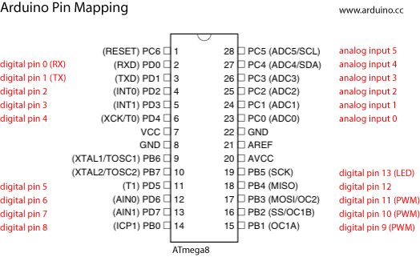

- Pins are wires connected to the microcontroller
- Pins are the interface of the microcontroller
- Pin voltages are *controlled* by a sketch
- Pin voltages can be *read* by a sketch

[figure not shown]

Input pins

- Input pins are controlled by other components
- Arduino reads the voltage on the pins
- Allows it to respond to events and data

Output pins

- Output pins are controlled by the Arduino
- Voltage is determined by your sketch
- Other components can be controlled through outputs

Digital vs Analog

- Some pins are digital-only
  - Read digital input, write digital output
  - 0 volts or 5 volts
- Some pins can be analog inputs
  - Can read analog voltages on the pin
  - Useful for analog sensors
- Analog-only pins are clearly labeled
- No pins can generate a true analog output

## Input/Ouput (I/O) in Arduino

- These functions allow access to the pins

```
void pinMode(pin, Mode)
```

Digital Input

```
int digitalRead(pin)
```

- Returns the state of an input pin
- Returns either `LOW` (0 volts) or `HIGH` (5 volts)

```
int pinval;
pinval = digitalRead(3);
```

- pinval is set to the state of digital pin3

Digital Output

```
void digitalWrite(pin, value)
```

- Assigns the state of an output pin
- Assigns either `LOW` (0 volts) or `HIGH` (5 volts)

```
digitalWrite(3, HIGH);
```

- Digital pin 3 is set `HIGH` (5 volts)

Analog Input

```
int analogRead(pin)
```

- Returns the state of an analog input pin
- Returns an integer from 0 to 1023
- 0 for 0 volts, 1023 for 5 volts

```
int pinval;
pinval = analogRead(A3);
```

- Pin must be an analog pin

Analog Output

- No pins can generate a true analog output
- But PWM can be used

# 2. Digital Input and Output

http://www.allaboutcircuits.com/projects/learn-how-to-use-the-arduinos-digital-i-o/

## 2.1. Lab 01: Blinking LED using delay

- the LED connects to digital I/O pin 8 of the Arduino through the 220 ohm resistor.
- The resistor controls the current through the LED.
- sets the digital I/O pin to HIGH for 1000 ms, then to LOW for another 1000 ms.

[figure not shown]

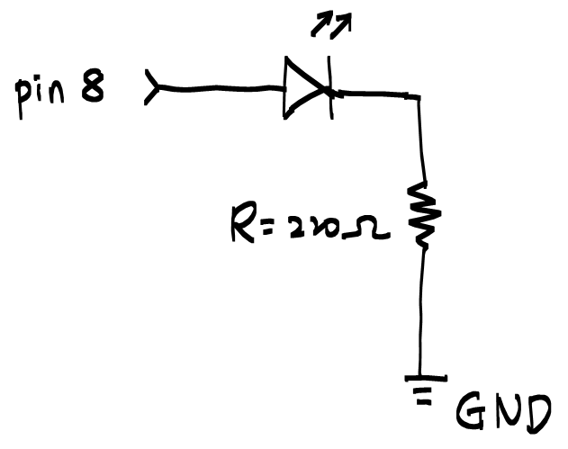

```python
%%html
<iframe src="https://www.youtube.com/embed/Q8rPASi2Br4?list=PLBD_gON7g_m0grsluFTqWhl5bCSfmSWR5?autoplay=0"
width="560" height="315" frameborder="0" allowfullscreen></iframe>
```

[video not shown]

```
const int led  =  8;        // use digital I/O pin 8

void setup() {
  pinMode(led, OUTPUT);     // set pin 8 to be an output output
}

void loop() {
  delay(1000);              // delay 1000 milliseconds
  digitalWrite(led, HIGH);  // set pin 8 HIGH, turning on LED
  delay(1000);              // delay 1000 milliseconds
  digitalWrite(led, LOW);   // set pin 8 LOW, turning off LED
}
```

## 2.2. Lab 02: Blinking LED using Button

- An LED is connected to pin 8, which is configured as an OUTPUT.
- A pushbutton is connected to pin 9, which is configured as an INPUT.
- When someone presses the pushbutton switch, pin 9 is set to HIGH, and the program will then set the output of pin 8 to HIGH and turning on the LED.
- Releasing the pushbutton resets pin 9 to LOW, then sets pin 8 to LOW, which turns off the LED.
- *debouncing* will be discussed later

[figure not shown]

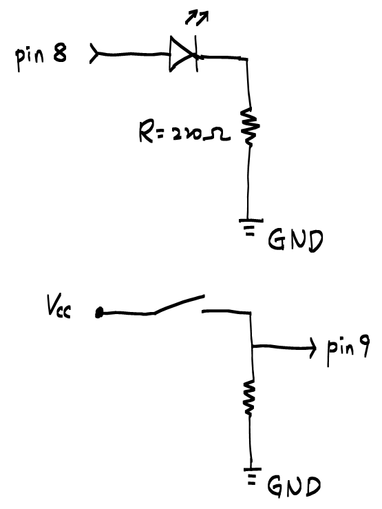

```python
%%html
<iframe src="https://www.youtube.com/embed/5APhIAi7Mzs?autoplay=0"
width="560" height="315" frameborder="0" allowfullscreen></iframe>
```

[video not shown]

```
const int led    =   8;       //name pin 8 as led
const int button =   9;       //name pin 9 as button

void setup() {
  pinMode(led, OUTPUT);       //set pin 8 as OUTPUT
  pinMode(button, INPUT)  ;   //set pin 9 as INPUT
}

void loop() {
  int reads = digitalRead(button);  //read the digital value on pin 9
  digitalWrite(led, reads);         //set the digital output value of pin 8 to that value
}
```

# 3. Analog Inputs and Output (or Pulse Width Modulation)

**Analog Inputs**

`int analogRead(pin)`

- Returns the state of an analog input pin
- Returns an integer from 0 to 1023 ($2^{10}$)
- 0 for 0 volts, 1023 for 5 volts

**Analog Outputs**

- No pins can generate a true analog output

**Pulse Width Modulation**

- Can be used for analog output
- Duty cycle is the percent of time the pulse is high
- Increasing duty cycle increases perceived voltage

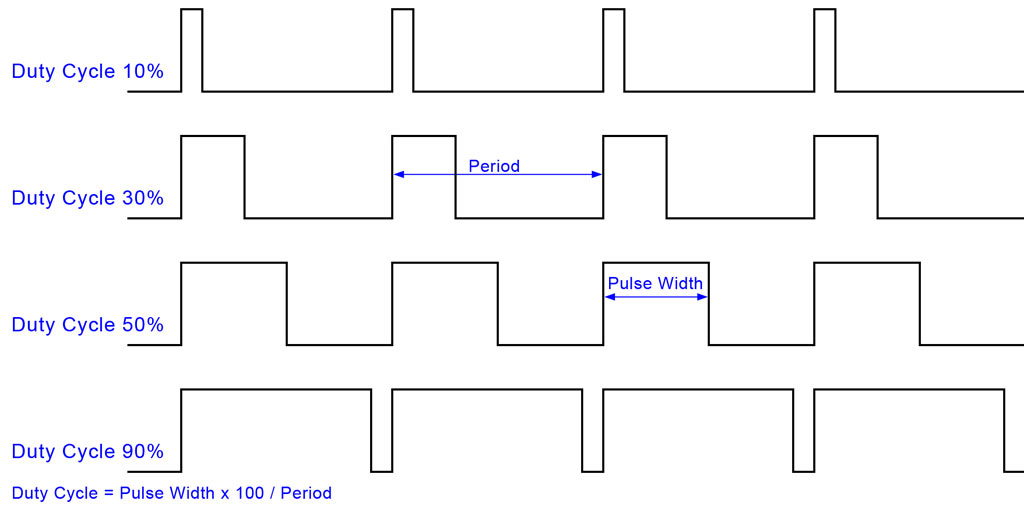

**`analogWrite()`**

- Generates a square wave on a pin, 490 Hz
- First argument is the pin number
- Second argument is the pulse width
  - 0 is 0% duty cycle
  - 255 is 100% duty cycle ($2^8$)
- Pin number must be a PWM pin
  - Marked on the Arduino with the ~ symbol
- For example: `analogWrite(9, 128)`

## 3.1. Lab 03: Fade LED In and Out (PWM)

- 220 ohm resistor
- Note that pin 9 is used

[figure not shown]

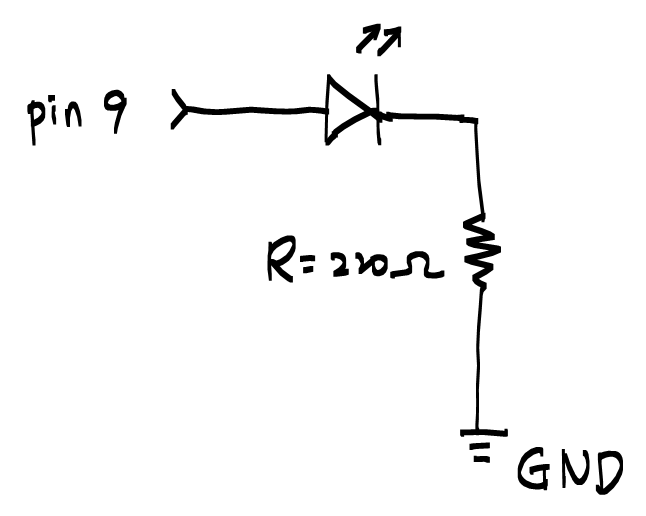

```python
%%html
<iframe src="https://www.youtube.com/embed/_HqUBLAbxSI?autoplay=0"
width="560" height="315" frameborder="0" allowfullscreen></iframe>
```

[video not shown]

```
int i = 0;
const int LED = 9;     //define the pin we use for LED

void setup() {
  pinMode(LED, OUTPUT); //set pin 9 as OUTPUT
}

void loop() {
  for (int i = 0; i < 255; i++) { //if i is less than 255 then increase i with 1
    analogWrite(LED, i);          //write the i value to pin 11
    delay(5);                     //wait 5 ms then do the for loop again
  }

  for (int i = 255; i > 0; i--) { //descrease i with 1
    analogWrite(LED, i);
    delay(5);
  }
}
```

# 4. Serial Communication

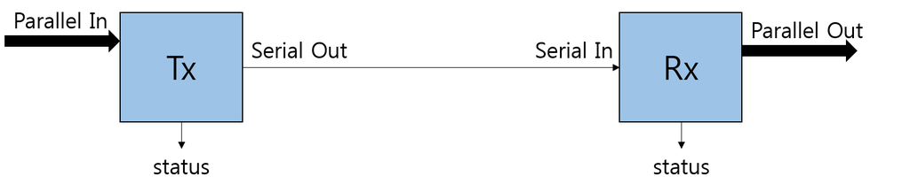

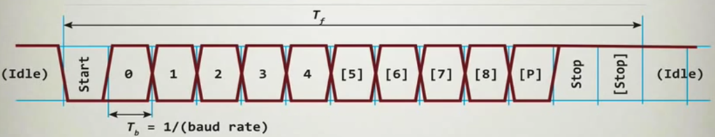

- UART protocol used over the USB cable
- One bit at a time
- Initialize by using `Serial.begin()`
- `Serial.begin(speed)`
  - `speed` is the baud rate
  - `Serial.begin(9600)`
- Usually call `Serial.begin()` in the setup function

**`Serial.available()`**

- Get the number of bytes (characters) available for reading from the serial port. This is data that's already arrived and stored in the serial receive buffer (which holds 64 bytes).

**`Serial.read()`**

- Reads incoming serial data.
- Returns the **first byte** of incoming serial data available (or -1 if no data is available)

**`Serial.print()`**

- https://www.arduino.cc/en/Serial/Print

**`Serial.println()`**: new line

```
int incomingByte = 0;   // for incoming serial data

void setup() {
  Serial.begin(9600);     // opens serial port, sets data rate to 9600 bps
}

void loop() {
  // send data only when you receive data:
  if (Serial.available() > 0) {
    // read the incoming byte:
    incomingByte = Serial.read();

    // say what you got:
    Serial.print("I received: ");
    Serial.println(incomingByte);
  }
}
```

**`Serial.write()`**

- Writes binary data (ASCII) to the serial port. This data is sent as a byte or series of bytes
- to send the characters representing the digits of a number use the `Serial.print()` function instead.
- Serial.write(val)
  - val: a value to send as a single byte
- Serial.write(str)
  - str: a string to send as a series of bytes

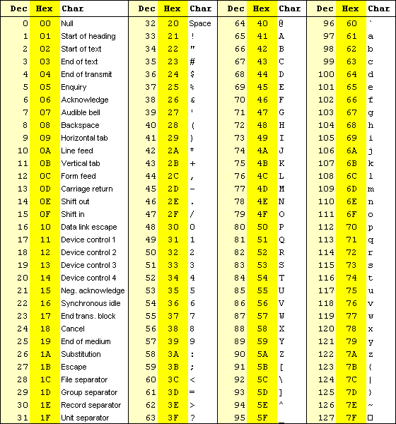

```
void setup() {
  Serial.begin(9600);
}

void loop() {
  Serial.write(45); // send a byte with the value 45

  int bytesSent = Serial.write("hello"); //send the string “hello” and return the length of the string.
}
```

## Debug via Serial Communication

- **`Serial.print()`**

```
int x = 0;

void setup() {
  Serial.begin(9600);
}

void loop() {
  Serial.println(x);
  if (x > 10) {
    x = 0;
  }
  else {
    x++;
  }
  delay(1000);
}
```

- **`Serial.write()`**

```
int x = 48;

void setup() {
  Serial.begin(9600);
}

void loop() {
  Serial.write(x);
  Serial.println(' ');
  if (x > 56) {
    x = 48;
  }
  else {
    x++;
  }
  delay(1000);
}
```

```python
%%html
<iframe src="https://www.youtube.com/embed/KYWCkdrCUKg"
width="560" height="315" frameborder="0" allowfullscreen></iframe>
```

[video not shown]

## 4.1. Lab 04: Serial Communication for Analog Inputs

[figure not shown]

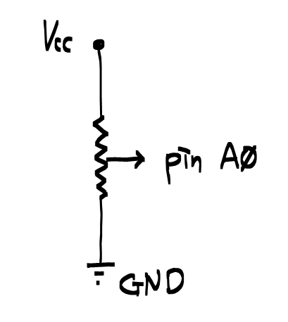

```python
%%html
<iframe src="https://www.youtube.com/embed/7Pq8BgJwo1w"
width="560" height="315" frameborder="0" allowfullscreen></iframe>
```

[video not shown]

```
void setup() {
  // initialize serial communication at 9600 bits per second:
  Serial.begin(9600);
}

// the loop routine runs over and over again forever:
void loop() {
  // read the input on analog pin 0:
  int sensorValue = analogRead(A0);

  // Convert the analog reading (which goes from 0 - 1023) to a voltage (0 - 5V):
  float voltage = sensorValue * (5.0 / 1023.0);

  // print out the value you read:
  Serial.println(voltage);
}
```

```python
%%javascript
$.getScript('https://kmahelona.github.io/ipython_notebook_goodies/ipython_notebook_toc.js')
```